# OCN 750 - HW 13.

Maia Kapur

Nov 15, 2015

#### For this assignment, Kyle suggested the following: “When you plot the residuals from a gls model, you want to use type =”normalized“, because these will account for the modeled residual structure. Your plots look autocorrelated, because they’re using the raw residuals.” Problem is, the acf() command doesn’t accept a normalized type argument. Not sure if this has been updated in your lecture notes or it may be worth asking him about.

```r
require(nlme)
require(geoR)
require(mgcv)
## just use these for plotting
library(ggplot2)
require(RMisc)
```

#### The question to ask is whether MHT actually causes the location of the marsh zones to shift from year to year. Start by just analyzing the zone M. Make some exploratory plots of Distance over time, and Distance vs. MHT. What do the patterns look like?

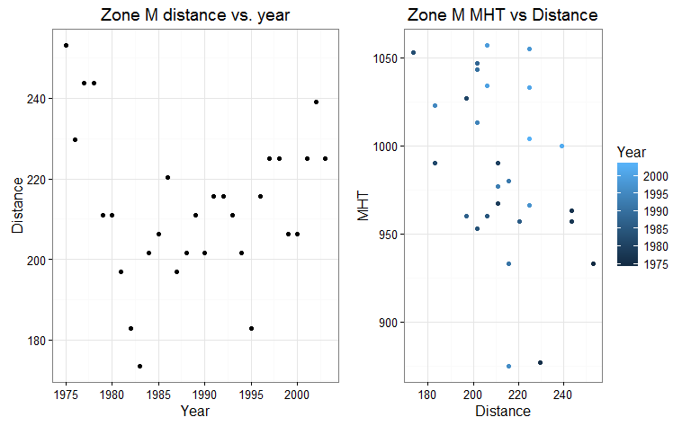

```r
marsh = read.csv('marsh_time_series.csv')
zonem = subset(marsh, marsh$Zone == 'M')
# par(mfrow = c(1,2))
# plot(Distance ~ Year, data = zonem, main = "distance vs. year")
# plot(MHT ~ Distance, data = zonem, main = "distance vs. MHT")
multiplot(
  ggplot(zonem, aes(x = Year, y = Distance))+
  theme_bw()+
  geom_point()+
  ggtitle("Zone M distance vs. year"),
ggplot(zonem, aes(x = Distance, y = MHT))+
  theme_bw()+
  geom_point(aes(color = Year))+
  ggtitle("Zone M MHT vs Distance"),
cols = 2)
```

```r
## it's hard to see any correlation here. Perhaps a slight negative trend in both plots (distance over time, MHT over distance).
```

#### Fit a linear model for Distance vs. MHT (just for zone M). Make an autocorrelationplot for the residuals of this model; does it look like the residuals are autocorrelated?

```r
#dev.off()
mmht = lm(Distance ~ MHT, data = zonem)
acf(resid(mmht))
## there only appears to be autocorrelation for the first time lag.
```

[output not shown]

#### Fit a generalized least squares model instead, using an AR(1) model for the residuals. Does this model account for the autocorrelation? What is the estimate for phi? Does the GLS model affect your inference about whether MHT affects the distance of the marsh zone?

```r
## applying AR1 correlation model within gls(); using Time Series data (not Distance)
mod.gls1 = gls(Distance ~ 1 + MHT, data = zonem, correlation = corAR1(form = ~Year))
summary(mod.gls1)
## the estimate for phi is ~ 0.7. The model defaults to value = 0, or 'no autocorrelation'. However, it appears MHT is an insignificant predictor of "distance".

#v1 = variog(coords = zonem[,'Distance'], data = resid(mod.gls1, type = "normalized")) ## not east, north
```

[output not shown]

#### Now we’ll use the data from all three zones. If there is a general effect across zones, this should be better estimated by using all the data. But we need to account for autocorrelation within each zone’s time series. Fit a GLS model to the data from all three zones, including predictors for MHT as well as the difference between zones in mean Distance. To model the autocorrelation within each zone, you can use AR(1) with a grouping factor, as described in ?corAR1.

```r
mod.gls2 = gls(Distance ~ MHT + Zone, data = marsh, correlation = corAR1(form = ~Year|Zone))
```